# Beispiel: Report

Raphael Schleutker und Hannah Schmitz

Oktober 2017

## Einleitung

Die folgende Analyse beschäftigt sich mit der Größe von Testis-Tubuli in unterschiedlichen Vögeln. Dazu wurden Paraffinschnitte der Tubuli am Mikroskop aufgenommen und anschließend vermessen. Für jeden Tubulus wurden sowohl der Gesamtdurchmesser als auch die Breite des umgebenden Epithels gemessen. Ausgehend von diesen Daten wurde die Fläche des Epithels sowie die Gesamtfläche des Tubulus gemessen und für jede Spezies ins Verhältnis zueinander gebracht.

Dieser Report fasst die wesentlichen Schritte und das Vorgehen zusammen und erklärt in diesem Zusammenhang die R-Skripte, welche für die Analyse erstellt wurden.

### Die Daten

Die Daten bestehen aus 15 Dateien, welche sich im Unterordner *./Data/* befinden. Der Name jeder Datei setzt sich aus der untersuchten Spezies, der jeweiligen Vogel-ID, der Messnummer, sowie einer Spezifizierung der Daten zusammen - jeweils durch ein _ getrennt. In dieser Analyse wurden lediglich die **Lines**-Daten untersucht.

```r
list.files("./Data/", pattern = "[^_]*_[^_]*_[^_]*_Lines.csv")
```

```
##  [1] "Canary_ID1_805_Lines.csv"        "Canary_ID2_818_Lines.csv"
##  [3] "Canary_ID3_807_Lines.csv"        "Canary_ID4_817_Lines.csv"
##  [5] "Crufica_16758_16_Lines.csv"      "Crufica_ID5_11_Lines.csv"
##  [7] "Crufica_ID6_12_Lines.csv"        "Crufica_ID7_13_Lines.csv"
##  [9] "Falke_Unknown_Unknown_Lines.csv" "Gimpel_ID8_Unknown_Lines.csv"
## [11] "Mbonari_ID10_16748_Lines.csv"    "Mbonari_ID11_16756_Lines.csv"
## [13] "Mbonari_ID9_16747_Lines.csv"     "ZF_ID12_717_Lines.csv"
## [15] "ZF_ID12_718_Lines.csv"
```

Jeder Datensatz ist identisch aufgebaut und besteht aus zwei Variablen:

- `Name` ist eine fortlaufende Messnummer.
- `Length [um]` gibt die gemessene Strecke in Mikrometern an.

Jeweils zwei Zeilen geben den Durchmesser für einen Tubulus an, gefolgt von vier Zeilen für die Epithelbreite. So ergeben sich für jeden Tubulus sechs Beobachtungen. Diese Information muss später durch zwei kategorische Variablen hinzugefügt werden.

```r
readr::read_csv("./Data/Canary_ID1_805_Lines.csv", comment = "#", skip = 1)
```

```
## # A tibble: 77 x 2
##    `Line 1` `758.02`
##       <chr>    <dbl>
##  1   Line 2   669.94
##  2   Line 3   114.63
##  3   Line 4    95.36
##  4   Line 5    86.30
##  5   Line 6    97.24
##  6   Line 7   781.48
##  7   Line 8   627.79
##  8   Line 9    87.53
##  9  Line 10    79.84
## 10  Line 11    99.82
## # ... with 67 more rows
```

## Daten einlesen und aufbereiten

Der folgende Code stammt aus *./Analysis/Reading.R*.

### Hilfsfunktion zum prozessieren der Daten

Um die Daten aufzubereiten, wurde eine Hilfsfunktion `Process_Line_Data()` geschrieben. Diese nimmt einen Datensatz als Listenelement und fügt auf Grundlage des Dateinamens, welches als `names`-Attribut hinterlegt ist, Die Vogel-ID, die Spezies sowie den Dateinamen des betreffenden Datensatzes hinzu. Außerdem werden zwei Variablen `Measured` und `Group` hinzugefügt, welche die Daten kategorisieren, wie in der Einleitung beschrieben wurde. Zuletzt wird noch die überflüssige `Name`-Variable von den Datensätzen entfernt. Der aufbereitete Datensatz wird als Listenelement zurückgeschickt, sodass die Funktion mit `purrr::lmap()` zusammenarbeitet.

```r
#' Creates function to process lines data. Works only when the Data argument is
#' a list with the appropriate dataframe as a list element. The function uses
#' the names of the named list passed in to assign the BirdID and the Species
#' variables to the dataframes. It also adds a column indicating what was
#' actually measured. This information was previously not provided by the
#' dataframe itself.

Process_Line_Data <- function(Data) {
  require(stringr)
  require(dplyr)

  Names = names(Data)
  Split = unlist(str_split(Names, "_"))
  Times = nrow(Data[[1]])/6

  Data <- Data[[1]] %>%
    mutate(Measured = rep(c("Diameter", "Diameter", "Width Epithelium", "Width Epithelium", "Width Epithelium", "Width Epithelium"),
                          times = Times)) %>%
    mutate(Group = rep(1:Times, each = 6)) %>%
    mutate(BirdID = Split[2]) %>%
    mutate(Species = Split[1]) %>%
    mutate(File = Names[[1]]) %>%
    select(-Name) %>%
    list()

  return(Data)
}
```

### Daten einlesen und aufbereiten

Um das Einlesen möglichst einfach zu halten, wurde zunächst ein Character-Vektor mit den Dateinamen erstellt, welche das vorgegebene Muster erfüllen, sodass von den Daten später nur die richtigen Dateien eingelesen werden. Anschließend bekommt jedes Vektorelement ein `name`-Attribut, sodass es später möglich ist, diesen an die Hilfsfunktion zu übergeben.

Mithilfe der `map()`-Funktion aus dem `purrr`-Paket wird nun jede Datei eingelesen, sodass man eine Liste mit den Datensätzen erhält. Anschließend werden dieser mit der `lmap()`-Funktion an die Hilfsfunktion geschickt. Die aufbereiteten Datensätze werden zusammengefügt und schließlich anhand der `Measured`-Variable in zwei Datensätze aufgetrennt, welche unabhängig voneinander bearbeitet werden können.

```r
#' The following lines read in and process the lines data. For this, the
#' appropriate files are first listed as a character vector. Each element is
#' named with the file name and read in by mapping over the character vector.
#' The resulting named list of dataframes is processed. Since the names metadata
#' is used for the processing, lmap() is used. The dataframes are then bound to
#' one dataframe and splitted by the measured variable.

library(readr)
library(dplyr)
library(purrr)

Lines <- list.files("./Data/", pattern = "[^_]*_[^_]*_[^_]*_Lines.csv") %>%
  setNames(make.names(.)) %>%
  map(~ read_csv(paste("./Data/", .x, sep = ""), comment = "#")) %>%
  lmap(~ Process_Line_Data(.x)) %>%
  bind_rows() %>%
  split(.$Measured)
```

## Analyse

Der folgende Code stammt aus *./Analysis/Analysis.R*.

```r
#' Calculate statistics of the diameter data. The data is first grouped by the
#' species, the BirdID, and the Group. Afterwards, all important values are
#' calculated. The calculated data is a new entry of the list.

Lines$Diameter_Analysis <- Lines$Diameter %>%
  group_by(Species, BirdID, Group) %>%
  summarise(n_Diameter = n(),
            Mean_Diameter = mean(`Length [um]`),
            SD_Diameter = sd(`Length [um]`),
            SE_Diameter = SD_Diameter/sqrt(n_Diameter),
            Mean_Radius = Mean_Diameter/2,
            SD_Radius = sd(`Length [um]`/2),
            SE_Radius = SD_Radius/sqrt(n_Diameter),
            Mean_Area = Mean_Radius^2*pi,
            SD_Area = sd((`Length [um]`/2)^2*pi),
            SE_Area = SD_Area/sqrt(n_Diameter))



Lines$WidthEpithelium_Analysis <- Lines$`Width Epithelium` %>%
  group_by(Species, Measured, BirdID, Group) %>%
  summarise(n_EpiWidth = n(),
            Mean_EpiWidth = mean(`Length [um]`),
            SD_EpiWidth = sd(`Length [um]`),
            SE_EpiWidth = SD_EpiWidth/sqrt(n_EpiWidth))



Lines$Analysis_Full <- full_join(Lines$Diameter_Analysis, Lines$WidthEpithelium_Analysis,
                                 by = c("Species", "BirdID", "Group")) %>%
  mutate(QuotientLength = Mean_EpiWidth/Mean_Radius) %>%
  mutate(AreaLumen = (Mean_Radius-Mean_EpiWidth)^2*pi) %>%
  mutate(AreaEpi = Mean_Area - AreaLumen) %>%
  mutate(QuotientArea = AreaEpi/Mean_Area) %>%
  group_by(Species) %>%
  summarise(n = n(),
            Mean_QuotientEpiRad = mean(QuotientLength),
            SD_QuotientEpiRad = sd(QuotientLength),
            Mean_QuotientArea = mean(QuotientArea),
            SD_QuotientArea = sd(QuotientArea))
```

## Grafische Auswertung

Der folgende Code stammt aus *./Analysis/Visualization.R*.

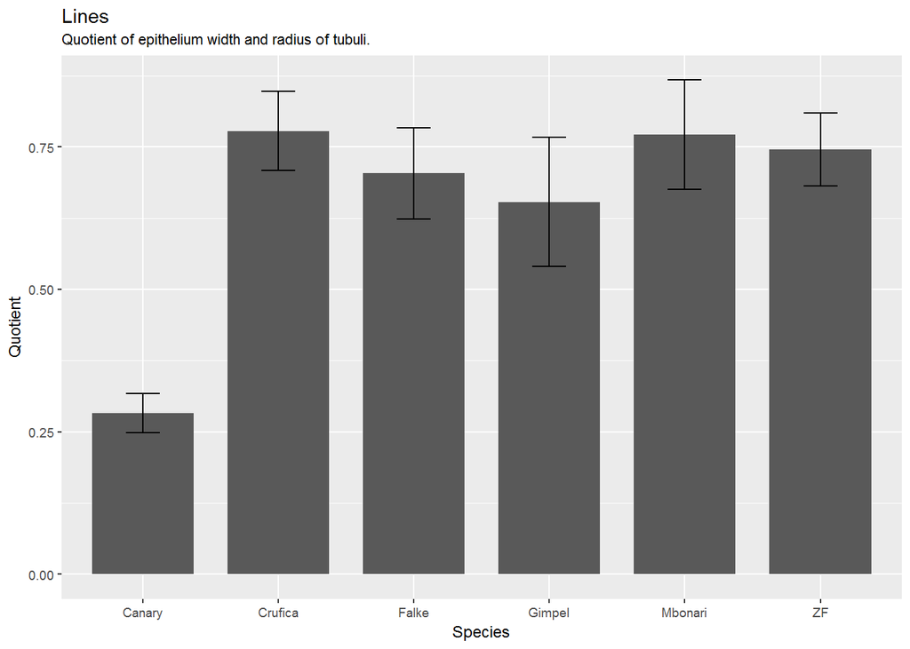

```r
#' Visualize the lines data as a barchart. Maps species on the x-axis and the
#' corresponding quotients of the epithelium width and radius as well as the
#' standard deviation on the y-axis.

library(ggplot2)

Lines$Plot <- ggplot(Lines$Analysis_Full, aes(Species, Mean_QuotientEpiRad)) +
  geom_bar(stat = "identity",
           position = position_identity(),
           width = .75) +
  geom_errorbar(mapping = aes(ymin = Mean_QuotientEpiRad - SD_QuotientEpiRad, ymax = Mean_QuotientEpiRad + SD_QuotientEpiRad),
                width = .25,
                size = .5) +
  scale_y_continuous(name = "Quotient") +
  labs(title = "Lines",
       subtitle = "Quotient of epithelium width and radius of tubuli.") +
  theme_gray(base_size = 9)


Lines$Plot
```

```r
#' Saves the previously created plot as a PDF file.

ggsave("./Results/Lines.pdf",
       plot = Lines$Plot,
       width = 80,
       height = 50,
       units = "mm")
```